# ESM 217 Lab 3: Modeling environment-health relationships

Author

Maxwell Pepperdine

Published

January 26, 2025

```r
rm(list=ls())
```

## Load packages

```r
library(tidyverse)
library(lubridate)
library(doBy)
library(mosaic)
library(car)
library(sf)
library(grDevices)
library(sjPlot)
library(here)
```

## Load data

```r
#read in dengue case data:
Den <- read.csv(here("data/Dengue_Confirmed_Peru.csv")) # change file path for your context
head(Den)
lapply(Den, class)

# read in MDD temperature data from GEE:
MDD_temp <- read.csv(here("data/MDD_Temperature.csv")) # change file path for your context
head(MDD_temp)

# read in MDD precipitation data from GEE:
MDD_precip <- read.csv(here("data/MDD_Precipitation.csv"))
```

## Data wrangling

#### Dengue data

```r
#make Date a date object
Den$Date <- as.Date(Den$Week_Yr)

#floor dates for later merging with environment data:
head(Den)
Den$Date_floored <- floor_date(Den$Date, "week")
head(Den)

Den_plot <- ggplot(Den, aes(x=Date_floored, y=Cases, col=as.factor(District))) +
  geom_point() + theme(legend.position="none")
Den_plot
```

#### MDD temp data

```r
#convert system.index to date:
MDD_temp$Date <- substr(MDD_temp$system.index, 1, 8)
head(MDD_temp)
MDD_temp$Date <- gsub('(.{4})(.{2})(.*)', '\\1-\\2-\\3', MDD_temp$Date)
head(MDD_temp)
MDD_temp <- MDD_temp[,c(2:4)]
MDD_temp$Date <- as.Date(MDD_temp$Date)
head(MDD_temp)

# floor dates to week to summarize:
MDD_temp$Date_floored <- floor_date(MDD_temp$Date, "week")
head(MDD_temp)
length(unique(MDD_temp$Date))
length(unique(MDD_temp$Date_floored))

MDD_temp_weekly <- summaryBy(mean ~ IDDIST + Date_floored, data=MDD_temp, FUN=mean)
head(MDD_temp_weekly)
colnames(MDD_temp_weekly)[1] <- "Dist_Code"
colnames(MDD_temp_weekly)[3] <- "Mean_Temp_C"
```

#### Merge the datasets

```r
### merge dengue and temperature data by floored dates:
Dengue_Temp <- merge(Den, MDD_temp_weekly,
                     by=c("Dist_Code", "Date_floored"),
                     all.x=F, all.y=F)
head(Dengue_Temp)
unique(Dengue_Temp$Year)
```

#### MDD precip data

```r
# convert system index to date:
MDD_precip$Date <- substr(MDD_precip$system.index, 1, 8)
head(MDD_precip)
MDD_precip$Date <- gsub('(.{4})(.{2})(.*)', '\\1-\\2-\\3', MDD_precip$Date)
head(MDD_precip)
MDD_precip <- MDD_precip[,c(2:4)]
MDD_precip$Date <- as.Date(MDD_precip$Date)
head(MDD_precip)

# floor dates to week to summarize:
MDD_precip$Date_floored <- floor_date(MDD_precip$Date, "week")
head(MDD_precip)
length(unique(MDD_precip$Date))
length(unique(MDD_precip$Date_floored))

MDD_precip_weekly <- summaryBy(mean ~ IDDIST + Date_floored, data=MDD_precip, FUN=mean)
head(MDD_precip_weekly)
colnames(MDD_precip_weekly)[1] <- "Dist_Code"
colnames(MDD_precip_weekly)[3] <- "Mean_Precip_m"
```

#### Merge the precip dataset to the dengue-temperature dataset

```r
### merge dengue-temperature and precipitation data by floored dates:
Dengue_Temp_Precip <- merge(Dengue_Temp, MDD_precip_weekly,
                            by=c("Dist_Code", "Date_floored"),
                            all.x=F, all.y=F)
head(Dengue_Temp_Precip)
```

## Data analysis

#### Only Dengue cases & temperature

```r
# standardize variables:
Dengue_Temp$Mean_Temp_C_std <- zscore(Dengue_Temp$Mean_Temp_C, na.rm=T)
hist(Dengue_Temp$Mean_Temp_C, n=50)
```

```r
hist(Dengue_Temp$Mean_Temp_C_std, n=50)
```

```r
Dengue_Temp$Cases_std <- zscore(Dengue_Temp$Cases, na.rm=T)
hist(Dengue_Temp$Cases, n=50)
```

```r
hist(Dengue_Temp$Cases_std, n=50)
```

```r
Dengue_Temp$log.Mean_Temp_C <- log(Dengue_Temp$Mean_Temp_C)
hist(Dengue_Temp$Mean_Temp_C, n=50)
```

```r
hist(Dengue_Temp$log.Mean_Temp_C, n=50)
```

```r
Dengue_Temp$log.Cases <- log(Dengue_Temp$Cases + 1)
hist(Dengue_Temp$Cases, n=50)
```

```r
hist(Dengue_Temp$log.Cases, n=50)
```

```r
#model dengue cases by temperature:
#head(Dengue_Temp)

Dengue_lm <- lm(
  log.Cases ~
    log.Mean_Temp_C
  + I(log.Mean_Temp_C^2)
  + factor(Year)
  + factor(Dist_Code)
  ,
  data=Dengue_Temp,
  na.action=na.exclude
)
summary(Dengue_lm)
```

```
Call:
lm(formula = log.Cases ~ log.Mean_Temp_C + I(log.Mean_Temp_C^2) +
    factor(Year) + factor(Dist_Code), data = Dengue_Temp, na.action = na.exclude)

Residuals:
    Min      1Q  Median      3Q     Max
-2.6986 -0.4321 -0.0919  0.2957  3.4317

Coefficients:
                         Estimate Std. Error t value Pr(>|t|)
(Intercept)             -40.19038   12.21078  -3.291 0.001003 **
log.Mean_Temp_C          26.75177    7.76360   3.446 0.000573 ***
I(log.Mean_Temp_C^2)     -4.17434    1.23370  -3.384 0.000720 ***
factor(Year)2011         -0.06524    0.03976  -1.641 0.100868
factor(Year)2012          0.03142    0.03983   0.789 0.430282
factor(Year)2013          0.11519    0.03983   2.892 0.003844 **
factor(Year)2014         -0.12035    0.03988  -3.018 0.002556 **
factor(Year)2015         -0.26297    0.03963  -6.636 3.53e-11 ***
factor(Year)2016         -0.37168    0.03958  -9.390  < 2e-16 ***
factor(Year)2017         -0.39434    0.03967  -9.941  < 2e-16 ***
factor(Year)2018         -0.17714    0.03981  -4.449 8.78e-06 ***
factor(Year)2019          0.58751    0.03967  14.809  < 2e-16 ***
factor(Dist_Code)170102  -1.69871    0.04153 -40.900  < 2e-16 ***
factor(Dist_Code)170103  -1.81009    0.04160 -43.512  < 2e-16 ***
factor(Dist_Code)170104  -2.20070    0.04158 -52.928  < 2e-16 ***
factor(Dist_Code)170201  -2.50062    0.04713 -53.062  < 2e-16 ***
factor(Dist_Code)170202  -2.58660    0.04187 -61.778  < 2e-16 ***
factor(Dist_Code)170203  -2.11633    0.04198 -50.409  < 2e-16 ***
factor(Dist_Code)170204  -2.00840    0.04338 -46.298  < 2e-16 ***
factor(Dist_Code)170301  -2.33458    0.04151 -56.240  < 2e-16 ***
factor(Dist_Code)170302  -1.99054    0.04154 -47.916  < 2e-16 ***
factor(Dist_Code)170303  -2.34293    0.04154 -56.400  < 2e-16 ***
---
Signif. codes:  0 '***' 0.001 '**' 0.01 '*' 0.05 '.' 0.1 ' ' 1

Residual standard error: 0.6692 on 5698 degrees of freedom
Multiple R-squared:  0.5465,    Adjusted R-squared:  0.5448
F-statistic:   327 on 21 and 5698 DF,  p-value: < 2.2e-16
```

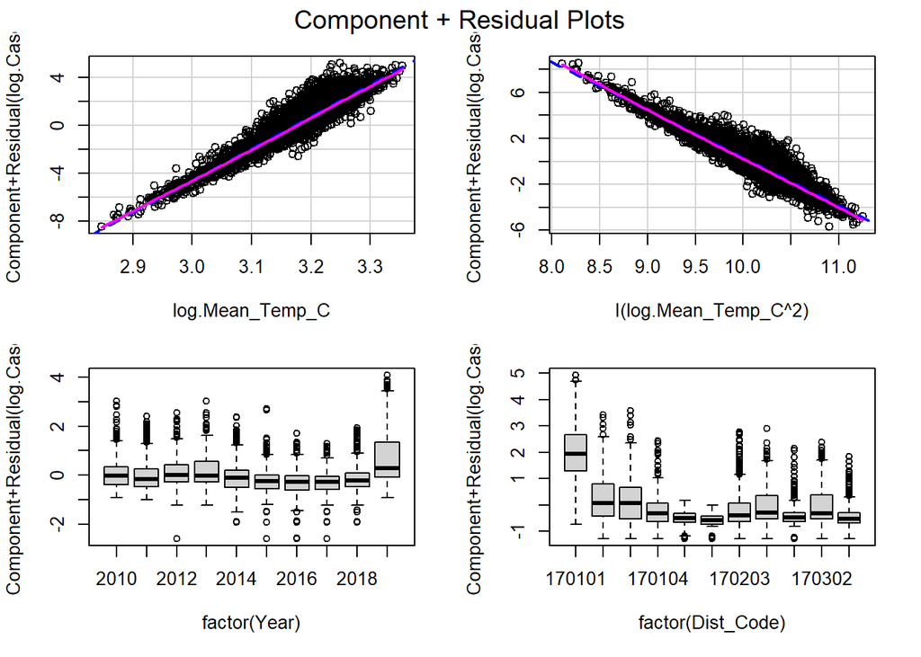

Figure 1: Regression diagnostics for the dengue temperature model.

```r
crPlots(Dengue_lm)
```

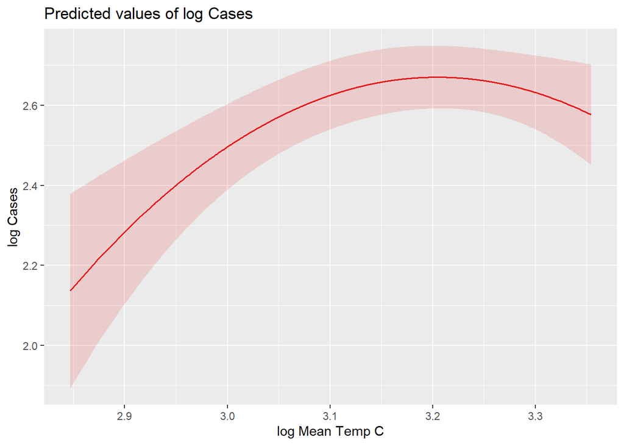

Figure 2: Predicted values from the dengue temperature model.

```r
plot_model(Dengue_lm, type = "pred",
           terms = "log.Mean_Temp_C", pred.type = "fe")
```

```r
#find at what temperature dengue peaks:
vertex <- -26.75177/(2*-4.17434)
vertex
```

```
[1] 3.204311
```

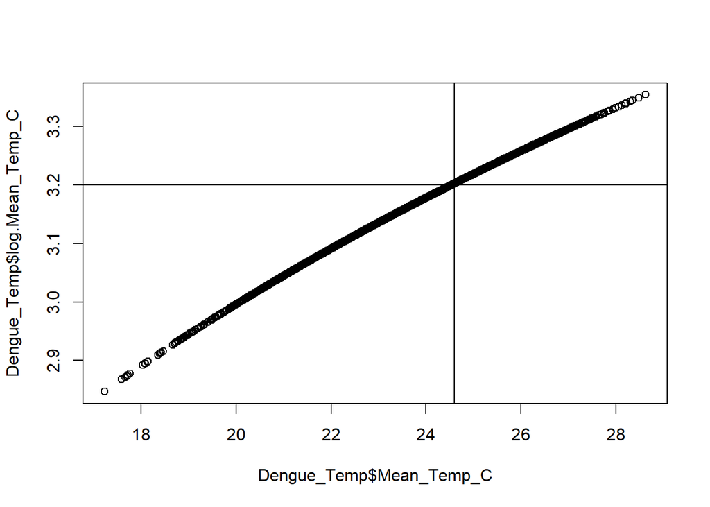

Figure 3: Predicted model values for which temperature dengue peaks at (~24.6 C).

```r
plot(Dengue_Temp$Mean_Temp_C, Dengue_Temp$log.Mean_Temp_C)
abline(h=3.2)
abline(v=24.6)
#looks like ~25 C, close to predicted thermal optimum for dengue transmitted by Aedes albopictus (25.4-27.6 C)
```

```r
#exploratory plots
Den_plot2 <- ggplot(Dengue_Temp, aes(x=Mean_Temp_C, y=Cases, col=as.factor(District))) +
  geom_point() + theme(legend.position="none")
Den_plot2
```

```r
Den_plot3 <- ggplot(Dengue_Temp, aes(x=Date_floored, y=Cases, col=as.factor(District))) +
  geom_point() + theme(legend.position="none")
Den_plot3
```

```r
Den_plot4 <- ggplot(Dengue_Temp, aes(x=Date_floored, y=Mean_Temp_C, col=as.factor(District))) +
  geom_line() #+ theme(legend.position="none")
Den_plot4
```

#### Adding precipitation to the model

```r
# standardize variables for temp & cases:
Dengue_Temp_Precip$Mean_Temp_C_std <- zscore(Dengue_Temp_Precip$Mean_Temp_C, na.rm=T)
hist(Dengue_Temp_Precip$Mean_Temp_C, n=50)
```

```r
hist(Dengue_Temp_Precip$Mean_Temp_C_std, n=50)
```

```r
Dengue_Temp_Precip$Cases_std <- zscore(Dengue_Temp_Precip$Cases, na.rm=T)
hist(Dengue_Temp_Precip$Cases, n=50)
```

```r
hist(Dengue_Temp_Precip$Cases_std, n=50)
```

```r
Dengue_Temp_Precip$log.Mean_Temp_C <- log(Dengue_Temp_Precip$Mean_Temp_C)
hist(Dengue_Temp_Precip$Mean_Temp_C, n=50)
```

```r
hist(Dengue_Temp_Precip$log.Mean_Temp_C, n=50)
```

```r
Dengue_Temp_Precip$log.Cases <- log(Dengue_Temp_Precip$Cases + 1)
hist(Dengue_Temp_Precip$Cases, n=50)
```

```r
hist(Dengue_Temp_Precip$log.Cases, n=50)
```

```r
# standardize variables for precip:
Dengue_Temp_Precip$Mean_Precip_m_std <- zscore(Dengue_Temp_Precip$Mean_Precip_m, na.rm=T)
hist(Dengue_Temp_Precip$Mean_Precip_m, n=50)
```

```r
hist(Dengue_Temp_Precip$Mean_Precip_m_std, n=50)
```

```r
Dengue_Temp_Precip$log.Mean_Precip_m <- log(Dengue_Temp_Precip$Mean_Precip_m + 1)
hist(Dengue_Temp_Precip$Mean_Precip_m, n=50)
```

```r
hist(Dengue_Temp_Precip$log.Mean_Precip_m, n=50)
```

```r
#model dengue cases by temperature and precipitation:
#head(Dengue_Temp_Precip)

Dengue_lm2 <- lm(
  log.Cases ~
    log.Mean_Temp_C
  + I(log.Mean_Temp_C^2)
  + log.Mean_Precip_m
  + I(log.Mean_Precip_m^2)
  + factor(Year)
  + factor(Dist_Code)
  ,
  data=Dengue_Temp_Precip,
  na.action=na.exclude
)

summary(Dengue_lm2)
```

```
Call:
lm(formula = log.Cases ~ log.Mean_Temp_C + I(log.Mean_Temp_C^2) +
    log.Mean_Precip_m + I(log.Mean_Precip_m^2) + factor(Year) +
    factor(Dist_Code), data = Dengue_Temp_Precip, na.action = na.exclude)

Residuals:
    Min      1Q  Median      3Q     Max
-2.6278 -0.4063 -0.0833  0.3041  3.3696

Coefficients:
                          Estimate Std. Error t value Pr(>|t|)
(Intercept)              8.645e+00  1.238e+01   0.698 0.485106
log.Mean_Temp_C         -3.956e+00  7.867e+00  -0.503 0.615051
I(log.Mean_Temp_C^2)     6.341e-01  1.249e+00   0.508 0.611688
log.Mean_Precip_m        3.584e+01  2.997e+00  11.958  < 2e-16 ***
I(log.Mean_Precip_m^2)  -5.413e+02  1.013e+02  -5.343 9.51e-08 ***
factor(Year)2011        -7.203e-02  3.898e-02  -1.848 0.064645 .
factor(Year)2012        -9.182e-05  3.909e-02  -0.002 0.998126
factor(Year)2013         9.263e-02  3.909e-02   2.370 0.017839 *
factor(Year)2014        -1.480e-01  3.912e-02  -3.783 0.000156 ***
factor(Year)2015        -2.870e-01  3.888e-02  -7.382 1.78e-13 ***
factor(Year)2016        -3.729e-01  3.880e-02  -9.612  < 2e-16 ***
factor(Year)2017        -4.165e-01  3.893e-02 -10.701  < 2e-16 ***
factor(Year)2018        -2.174e-01  3.912e-02  -5.557 2.87e-08 ***
factor(Year)2019         5.646e-01  3.891e-02  14.509  < 2e-16 ***
factor(Dist_Code)170102 -1.738e+00  4.080e-02 -42.604  < 2e-16 ***
factor(Dist_Code)170103 -1.803e+00  4.078e-02 -44.215  < 2e-16 ***
factor(Dist_Code)170104 -2.228e+00  4.080e-02 -54.618  < 2e-16 ***
factor(Dist_Code)170201 -2.639e+00  4.713e-02 -56.000  < 2e-16 ***
factor(Dist_Code)170202 -2.583e+00  4.104e-02 -62.921  < 2e-16 ***
factor(Dist_Code)170203 -2.180e+00  4.136e-02 -52.716  < 2e-16 ***
factor(Dist_Code)170204 -2.126e+00  4.336e-02 -49.045  < 2e-16 ***
factor(Dist_Code)170301 -2.302e+00  4.074e-02 -56.519  < 2e-16 ***
factor(Dist_Code)170302 -1.960e+00  4.076e-02 -48.080  < 2e-16 ***
factor(Dist_Code)170303 -2.322e+00  4.074e-02 -57.002  < 2e-16 ***
---
Signif. codes:  0 '***' 0.001 '**' 0.01 '*' 0.05 '.' 0.1 ' ' 1

Residual standard error: 0.6559 on 5696 degrees of freedom
Multiple R-squared:  0.5645,    Adjusted R-squared:  0.5628
F-statistic: 321.1 on 23 and 5696 DF,  p-value: < 2.2e-16
```

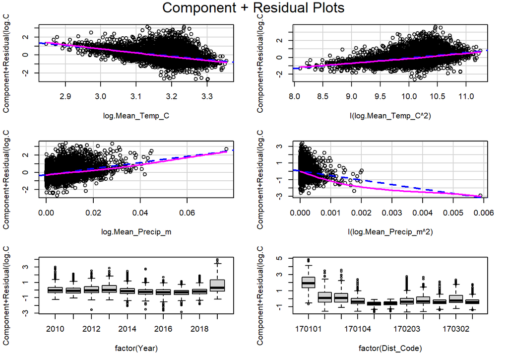

Figure 4: Regression diagnostics for the dengue temperature-precipitation model.

```r
crPlots(Dengue_lm2)
```

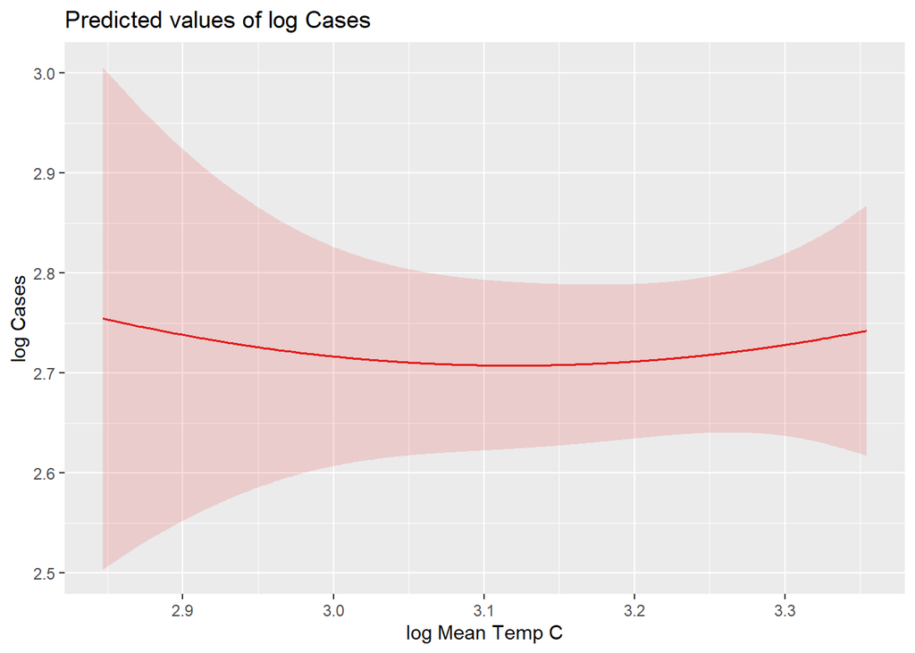

Figure 5: Predicted temperature values from the dengue temperature-precipitation model.

```r
plot_model(Dengue_lm2, type = "pred",
           terms = "log.Mean_Temp_C",
           pred.type = "fe")
```

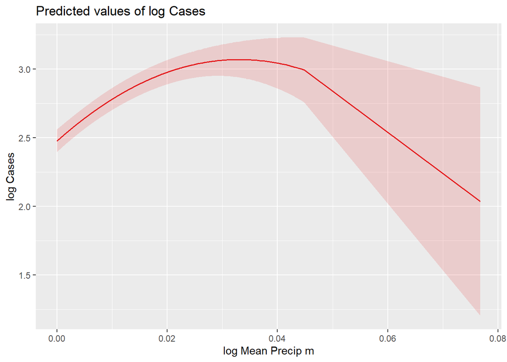

Figure 6: Predicted precipitaton values from the dengue temperature-precipitation model.

```r
plot_model(Dengue_lm2, type = "pred",
           terms = "log.Mean_Precip_m",
           pred.type = "fe")
```

```r
#exploratory plots
Den_plot5 <- ggplot(Dengue_Temp_Precip, aes(x=Mean_Temp_C, y=Cases, col=as.factor(District))) +
  geom_point() + theme(legend.position="none")
Den_plot5
```

```r
Den_plot6 <- ggplot(Dengue_Temp_Precip, aes(x=Mean_Precip_m, y=Cases, col=as.factor(District))) +
  geom_point() + theme(legend.position="none")

Den_plot7 <- ggplot(Dengue_Temp_Precip, aes(x=Date_floored, y=Cases, col=as.factor(District))) +
  geom_point() + theme(legend.position="none")
```

## Takeaways

#### Temp only model:

Looking at the regression results when running a model with only temperature, a one unit increase in `log.Mean_Temp_C` increases the dependent variables, `log.Cases`, ~by 26.75 units, holding all else constant. A one unit increase in `log.Mean_Temp_C^2` decreases the dependent variable, `log.Cases`, by ~4.17 units, holding all else constant. This suggests that the effect of temperature on dengue cases is nonlinear with the following traits:

- At lower temperatures, an increase in temperature has a positive effect on dengue cases.
- At higher temperatures, the effect starts to decrease, and an increase in temperature has either a smaller effect or negative effect on dengue cases.

#### Temp & precipitation model:

After repeating this analysis with precipitation added to the model, we see that both temperature variables (`log.Mean_Temp_C` & `log.Mean_Temp_C^2`) no longer have a significant effect on dengue cases. Precipitation, however, follows a similar trend to temperature in the temperature only model where:

- a one unit increase in `log.Mean_Precip_m` increases the dependent variable, `log.Cases`, by ~35.84 units, holding all else constant; and
- a one unit increase in `log.Mean_Precip_m^2` decreases the dependent variable, `log.Cases`, by ~541.3 units, holding all else constant.

This suggests that the effect of precipitation on dengue cases is also nonlinear with the following traits:

- At lower precipitation levels, an increase in precipitation has a positive effect on dengue cases.
- Beyond a certain precipitation level, the effect starts to decrease, and an increase in precipitation has either a smaller effect or negative effect on dengue cases.